# Predictive Analysis of FAI scales

Development of the FAI Scale

Author

Corrado Caudek

Published

January 22, 2025

## Background

This study aims to develop a psychological scale (FAI) to differentiate between family caregivers of children with chronic illnesses based on their coping abilities. This scale will identify caregivers who may benefit from additional support or interventions.

In this analysis, the severity of illnesses (`nome_malattia_raggruppato`) will be used as the criterion variable to evaluate the classification ability of the FAI scales.

Key questions:

1. Are the FAI scales adequate predictors of illness severity?
2. How well do statistical and machine learning models perform in predicting severity?
3. What conclusions can be drawn about the utility of the FAI scales?

## Load packages and options

```r
if (!requireNamespace("pacman")) install.packages("pacman")

pacman::p_load(
  here, tidyverse, TAM, mirt, lavaan, mokken, psych, semTools, MASS, brant,
  ids, pROC, nnet, caret, ROSE, DMwR, recipes, themis, randomForest, reshape2,
  VGAM, pdp
)

# Disable significance stars globally
options(show.signif.stars = FALSE)
```

## Import and Preprocess Data

### Load Data

```r
# Set working directory for RedCap data
setwd("~/_repositories/meyer_fai/scripts/redcap")

# Source helper functions
source(here::here("scripts", "redcap", "_targets.R"))

# Read cleaned RedCap data
temp <- tar_read(fai_clean_complete)
# Remove problematic cases based on prior analysis
temp1 <- temp[-c(12, 18, 76, 81, 152, 182, 193, 202), ]
# Remove outlier identified previously
fai_clean_complete <- temp1[-92, ]
rm(temp, temp1)

# Select and rename relevant variables
fai <- fai_clean_complete |>
  dplyr::select(
    fai_child_charact, fai_caregiving, fai_cure, fai_intrapsych,
    fai_support, fai_hyper, quanti_fratelli, sesso, nome_malattia,
    eta_pz, legge_104
  ) |>
  dplyr::rename(
    fai_child_char = fai_child_charact,
    fai_caregiving = fai_caregiving,
    fai_percz_cure = fai_cure,
    fai_intra_psyc = fai_intrapsych,
    fai_soc_fam_sp = fai_support,
    fai_hyper_prot = fai_hyper
  )
```

Create target variable.

```r
fai <- fai |>
  mutate(
    nome_malattia_raggruppato = case_when(
      nome_malattia %in% c(
        "glioma", "LLA", "linfoma anaplastico", "Leucemia mieloide",
        "fibrosi cistica", "Pinealoblastoma",
        "tumore glioneurale leptomeningeale diffuso"
      ) ~ "Molto grave",

      nome_malattia %in% c(
        "Epilessia", "sindrome di charge", "Distrofia muscolare",
        "Neurofibromatosi", "diabete di tipo 1", "artrite romatoide",
        "RCU", "emofilia"
      ) ~ "Grave",

      nome_malattia %in% c(
        "asma", "Emicrania", "dermatite atopica", "ipospadia",
        "ipotonia muscolare", "Blefaro chetato congiuntivite"
      ) ~ "Moderata",

      TRUE ~ "Lieve"
    )
  )

fai$nome_malattia_raggruppato <- factor(fai$nome_malattia_raggruppato)
fai$nome_malattia_raggruppato <-
  relevel(fai$nome_malattia_raggruppato, ref = "Lieve")

fai$nome_malattia <- NULL
```

## Exploratory Data Analysis

### Check for Missing Values

```r
# Ensure no missing values are present
sum(is.na(fai))
```

```
[1] 0
```

### Inspect Class Distribution

```r
# Check class balance
table(fai$nome_malattia_raggruppato)
```

```
      Lieve       Grave    Moderata Molto grave
        181           9           7           7
```

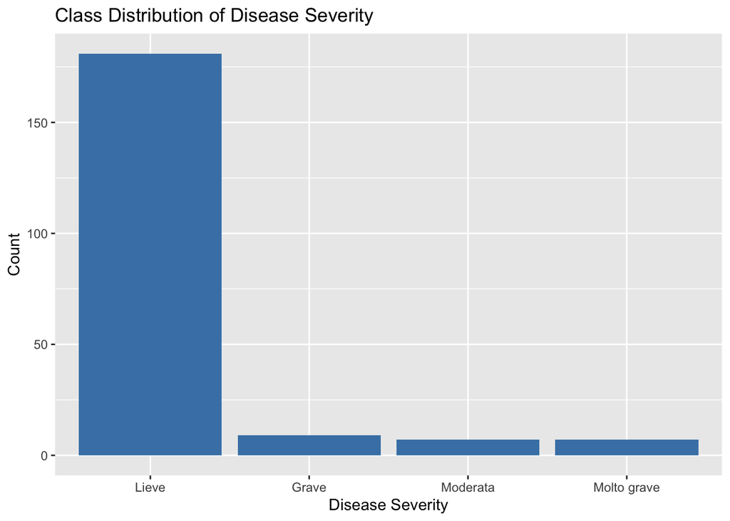

```r
# Visualize class proportions
ggplot(data.frame(fai$nome_malattia_raggruppato),
       aes(x = fai$nome_malattia_raggruppato)) +
  geom_bar(fill = "steelblue") +
  labs(
    title = "Class Distribution of Disease Severity",
    x = "Disease Severity",
    y = "Count"
  )
```

## Addressing Class Imbalance

Due to the extreme imbalance in class distribution, oversampling is used to balance the classes.

```r
set.seed(123)

# Balance dataset using oversampling
recipe_obj <- recipe(
  nome_malattia_raggruppato ~ fai_child_char + fai_caregiving +
    fai_percz_cure + fai_intra_psyc + fai_soc_fam_sp + fai_hyper_prot +
    eta_pz + quanti_fratelli,
  data = fai
) %>%
  step_upsample(nome_malattia_raggruppato, over_ratio = 1)

balanced_fai <- prep(recipe_obj) %>% juice()

# Confirm balanced classes
table(balanced_fai$nome_malattia_raggruppato)
```

```
      Lieve       Grave    Moderata Molto grave
        181         181         181         181
```

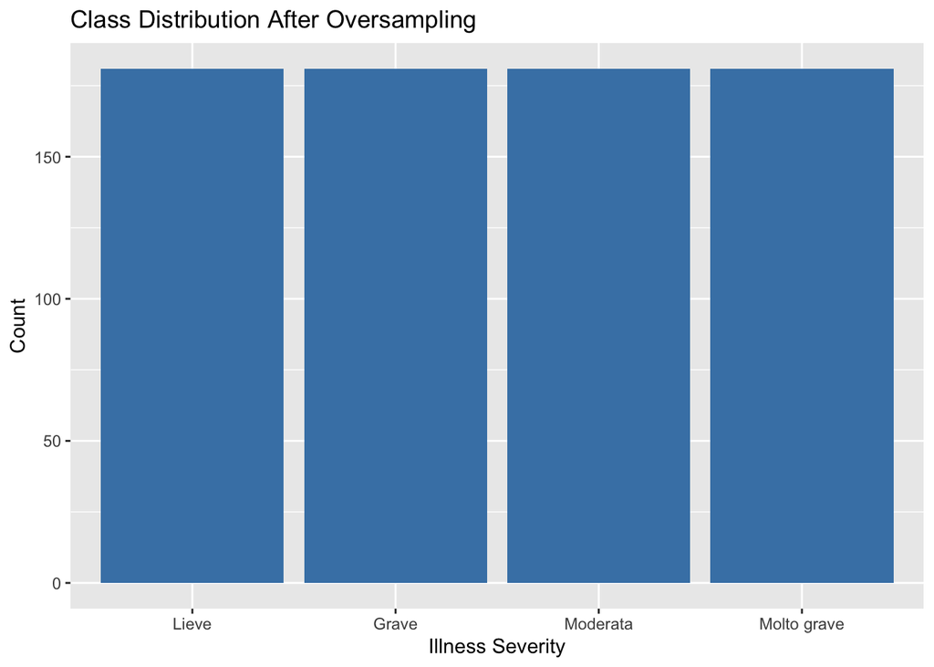

```r
# Visualize class distribution
balanced_fai |>
  ggplot(aes(x = nome_malattia_raggruppato)) +
  geom_bar(fill = "steelblue") +
  labs(
    title = "Class Distribution After Oversampling",
    x = "Illness Severity",
    y = "Count"
  )
```

## Predictive Modeling

### Multinomial Logistic Regression

```r
set.seed(123)

# Fit multinomial logistic regression
multinom_model <- nnet::multinom(
  nome_malattia_raggruppato ~ fai_child_char + fai_caregiving +
    fai_percz_cure + fai_intra_psyc + fai_soc_fam_sp + fai_hyper_prot +
    eta_pz + quanti_fratelli,
  data = balanced_fai
)
# Model summary
summary(multinom_model)
```

```
Call:
nnet::multinom(formula = nome_malattia_raggruppato ~ fai_child_char +
    fai_caregiving + fai_percz_cure + fai_intra_psyc + fai_soc_fam_sp +
    fai_hyper_prot + eta_pz + quanti_fratelli, data = balanced_fai)

Coefficients:
            (Intercept) fai_child_char fai_caregiving fai_percz_cure
Grave         -8.312101      0.1352074      0.6177829      0.3461817
Moderata      -7.110467     -0.2030494      0.7775226     -0.1558480
Molto grave  -52.187541     -0.8268725      3.4180444      2.7540684
            fai_intra_psyc fai_soc_fam_sp fai_hyper_prot      eta_pz
Grave           -0.1189766     0.04321949     -0.1540013 -0.03681603
Moderata         0.3856653     0.16207168      0.1039767 -0.25031581
Molto grave     -1.6536228    -0.79423530     -1.5240826  0.48179834
            quanti_fratelli
Grave             0.8811121
Moderata          1.3561272
Molto grave       2.0288669

Std. Errors:
            (Intercept) fai_child_char fai_caregiving fai_percz_cure
Grave          1.410178     0.05811952     0.08114556     0.04607942
Moderata       1.286926     0.07823077     0.08950918     0.03125462
Molto grave   11.482843     0.30690806     0.52034632     0.49021772
            fai_intra_psyc fai_soc_fam_sp fai_hyper_prot     eta_pz
Grave           0.06413781     0.06837788     0.04618566 0.02585094
Moderata        0.07266828     0.06422633     0.04528459 0.04387866
Molto grave     0.50540946     0.29821326     0.35098882 0.09533886
            quanti_fratelli
Grave             0.1944287
Moderata          0.2146990
Molto grave       0.9013128

Residual Deviance: 754.3104
AIC: 808.3104
```

#### Model Evaluation

Calculate z-values and p-values for model coefficients.

```r
# Evaluate model fit
z_values <- summary(multinom_model)$coefficients / summary(multinom_model)$standard.errors
p_values <- (1 - pnorm(abs(z_values), 0, 1)) * 2

# Display p-values
print(p_values)
```

```
             (Intercept) fai_child_char fai_caregiving fai_percz_cure
Grave       3.761280e-09    0.019998961   2.664535e-14   5.795364e-14
Moderata    3.291895e-08    0.009444841   0.000000e+00   6.151528e-07
Molto grave 5.498030e-06    0.007055722   5.072653e-11   1.931230e-08
            fai_intra_psyc fai_soc_fam_sp fai_hyper_prot       eta_pz
Grave         6.359418e-02    0.527342275   8.548464e-04 1.543984e-01
Moderata      1.113197e-07    0.011621085   2.167171e-02 1.165291e-08
Molto grave   1.068471e-03    0.007737538   1.410284e-05 4.337050e-07
            quanti_fratelli
Grave          5.848312e-06
Moderata       2.677054e-10
Molto grave    2.438471e-02
```

Predictions and Confusion Matrix

```r
# Confusion matrix and accuracy
predicted <- predict(multinom_model, balanced_fai)
conf_matrix <- table(Predicted = predicted, Actual = balanced_fai$nome_malattia_raggruppato)
conf_matrix
```

```
             Actual
Predicted     Lieve Grave Moderata Molto grave
  Lieve         118    30       22           0
  Grave          19   126        0           0
  Moderata       39    25      159           0
  Molto grave     5     0        0         181
```

```r
accuracy <- mean(predicted == balanced_fai$nome_malattia_raggruppato)
cat("Multinomial Accuracy:", round(accuracy, 2))
```

```
Multinomial Accuracy: 0.81
```

Compare accuracy to baseline (random guessing).

```r
# Calculate the baseline accuracy (random guessing)
baseline_accuracy <- 1 / nlevels(balanced_fai$nome_malattia_raggruppato)
print(paste("Baseline Accuracy:", round(baseline_accuracy, 2)))
```

```
[1] "Baseline Accuracy: 0.25"
```

## Cross-Validation

```r
set.seed(123)

# Perform 10-fold cross-validation to evaluate the model's generalizability
train_control <- trainControl(method = "cv", number = 10)
cv_model <- train(
  nome_malattia_raggruppato ~ fai_child_char + fai_caregiving +
    fai_percz_cure + fai_intra_psyc + fai_soc_fam_sp + fai_hyper_prot +
    eta_pz + quanti_fratelli,
  data = balanced_fai,
  method = "multinom",
  trControl = train_control
)
```

```r
# Print cross-validation results
print(cv_model)
```

```
Penalized Multinomial Regression

724 samples
  8 predictor
  4 classes: 'Lieve', 'Grave', 'Moderata', 'Molto grave'

No pre-processing
Resampling: Cross-Validated (10 fold)
Summary of sample sizes: 651, 652, 651, 651, 652, 652, ...
Resampling results across tuning parameters:

  decay  Accuracy   Kappa
  0e+00  0.8066020  0.7421541
  1e-04  0.8066020  0.7421541
  1e-01  0.7982686  0.7310361

Accuracy was used to select the optimal model using the largest value.
The final value used for the model was decay = 1e-04.
```

## Relative Importance of Predictors

Display Variable Importance.

```r
set.seed(123)

# Assess variable importance using caret
importance_model <- varImp(cv_model, scale = FALSE)
print(importance_model)
```

```
multinom variable importance

                Overall
fai_caregiving    4.776
quanti_fratelli   4.248
fai_percz_cure    3.215
fai_intra_psyc    2.153
fai_hyper_prot    1.769
fai_child_char    1.167
fai_soc_fam_sp    1.001
eta_pz            0.760
```

Visualize relative importance.

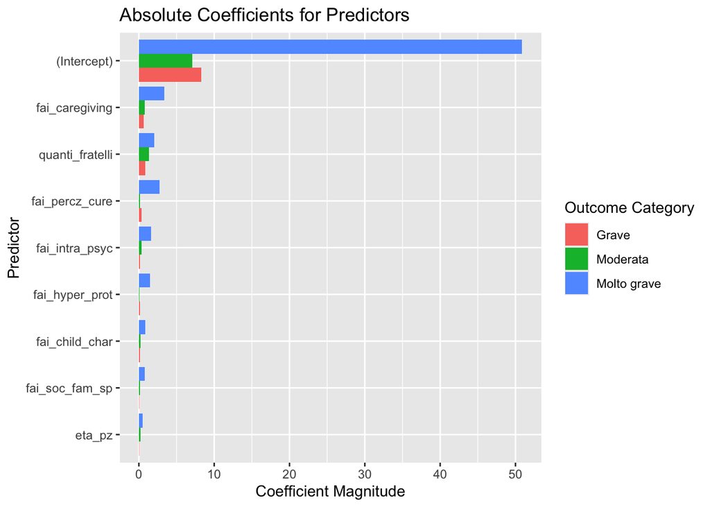

```r
# Extract and reshape coefficient data for plotting
coef_data <- as.data.frame(t(summary(cv_model)$coefficients))
coef_data$Variable <- rownames(coef_data)

# Reshape the coefficients for visualization
coef_long <- reshape2::melt(coef_data, id.vars = "Variable")

# Plot absolute coefficient values for predictors
ggplot(
  coef_long,
  aes(x = reorder(Variable, abs(value)), y = abs(value), fill = variable)
) +
  geom_bar(stat = "identity", position = "dodge") +
  coord_flip() +
  labs(
    title = "Absolute Coefficients for Predictors",
    x = "Predictor",
    y = "Coefficient Magnitude",
    fill = "Outcome Category"
  )
```

### Nonparametric Machine Learning

Random Forest is used as a nonparametric alternative, as it can capture nonlinearities and interactions.

#### 1. Baseline Random Forest Model

- Purpose: Establish a benchmark for model performance on the full oversampled dataset.
- Justification: Offers insights into the maximum possible fit but risks overfitting as the model is trained and evaluated on the same data.
- Accuracy: High training accuracy due to full variability capture.
- Limitation: Overestimation of generalization performance as unseen data is not tested.

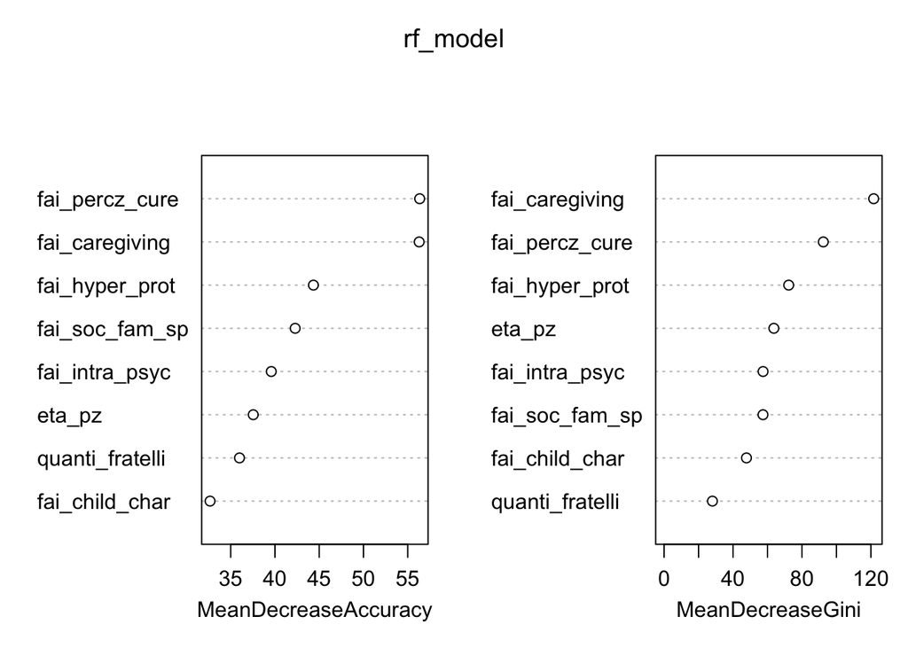

```r
# Fit Random Forest model
set.seed(123)

# Fit Random Forest model
rf_model <- randomForest(
  nome_malattia_raggruppato ~ fai_child_char + fai_caregiving + fai_percz_cure +
    fai_intra_psyc + fai_soc_fam_sp + fai_hyper_prot + eta_pz + quanti_fratelli,
  data = balanced_fai,
  ntree = 500,
  importance = TRUE
)

# Variable importance
varImpPlot(rf_model)
```

Model Performance

```r
# Confusion matrix and accuracy
rf_predictions <- predict(rf_model, balanced_fai)
rf_conf_matrix <- table(Predicted = rf_predictions, Actual = balanced_fai$nome_malattia_raggruppato)
rf_conf_matrix
```

```
             Actual
Predicted     Lieve Grave Moderata Molto grave
  Lieve         181     0        0           0
  Grave           0   181        0           0
  Moderata        0     0      181           0
  Molto grave     0     0        0         181
```

```r
rf_accuracy <- sum(diag(rf_conf_matrix)) / sum(rf_conf_matrix)
cat("Random Forest Accuracy:", round(rf_accuracy, 2))
```

```
Random Forest Accuracy: 1
```

#### 2. Train-Test Split Random Forest

In this version, the data was split into a training set (70%) and a testing set (30%), and the RF model was refitted on the training data and evaluated on the test data. The key aspects include:

- Purpose: Introduce a more realistic evaluation by training on 70% of the data and testing on the remaining 30%.
- Justification: Prevents overfitting by validating on unseen data, providing an honest estimate of performance.
- Accuracy: Slightly reduced test accuracy compared to the baseline model, reflecting more realistic generalization.
- Limitation: Results depend on a single train-test split, which can introduce bias.

```r
set.seed(123)
train_index <- createDataPartition(
  balanced_fai$nome_malattia_raggruppato, p = 0.7, list = FALSE)
train_data <- balanced_fai[train_index, ]
test_data <- balanced_fai[-train_index, ]

# Refit the Random Forest model on the training data
rf_model <- randomForest(
  nome_malattia_raggruppato ~ fai_child_char + fai_caregiving + fai_percz_cure +
    fai_intra_psyc + fai_soc_fam_sp + fai_hyper_prot + eta_pz + quanti_fratelli,
  data = train_data,
  ntree = 500,
  importance = TRUE
)

# Predict on the test data
rf_predictions_test <- predict(rf_model, test_data)

# Confusion matrix and accuracy
rf_conf_matrix_test <- table(Predicted = rf_predictions_test, Actual = test_data$nome_malattia_raggruppato)
rf_conf_matrix_test
```

```
             Actual
Predicted     Lieve Grave Moderata Molto grave
  Lieve          53     0        0           0
  Grave           1    54        0           0
  Moderata        0     0       54           0
  Molto grave     0     0        0          54
```

```r
rf_accuracy_test <- sum(diag(rf_conf_matrix_test)) / sum(rf_conf_matrix_test)
cat("Random Forest Test Accuracy:", round(rf_accuracy_test, 2))
```

```
Random Forest Test Accuracy: 1
```

```r
set.seed(123)
train_control <- trainControl(method = "cv", number = 10)

cv_model <- train(
  nome_malattia_raggruppato ~ fai_child_char + fai_caregiving + fai_percz_cure +
    fai_intra_psyc + fai_soc_fam_sp + fai_hyper_prot + eta_pz + quanti_fratelli,
  data = balanced_fai,
  method = "rf",
  trControl = train_control
)

print(cv_model)
```

```
Random Forest

724 samples
  8 predictor
  4 classes: 'Lieve', 'Grave', 'Moderata', 'Molto grave'

No pre-processing
Resampling: Cross-Validated (10 fold)
Summary of sample sizes: 651, 652, 651, 651, 652, 652, ...
Resampling results across tuning parameters:

  mtry  Accuracy   Kappa
  2     0.9958714  0.9944945
  5     0.9917428  0.9889894
  8     0.9806697  0.9742261

Accuracy was used to select the optimal model using the largest value.
The final value used for the model was mtry = 2.
```

#### 3. Regularized and Cross-Validated Random Forest

```r
set.seed(123)
rf_model_regularized <- randomForest(
  nome_malattia_raggruppato ~ fai_child_char + fai_caregiving + fai_percz_cure +
    fai_intra_psyc + fai_soc_fam_sp + fai_hyper_prot + eta_pz + quanti_fratelli,
  data = train_data,
  ntree = 500,
  maxnodes = 20, # Restrict tree size
  mtry = 3 # Reduce predictors at each split
)

# Predict on test data
rf_predictions_test_regularized <- predict(rf_model_regularized, test_data)

# Confusion matrix and accuracy
rf_conf_matrix_test_regularized <- table(Predicted = rf_predictions_test_regularized, Actual = test_data$nome_malattia_raggruppato)
rf_accuracy_test_regularized <- sum(diag(rf_conf_matrix_test_regularized)) / sum(rf_conf_matrix_test_regularized)
cat("Random Forest Regularized Test Accuracy:", round(rf_accuracy_test_regularized, 2))
```

```
Random Forest Regularized Test Accuracy: 0.97
```

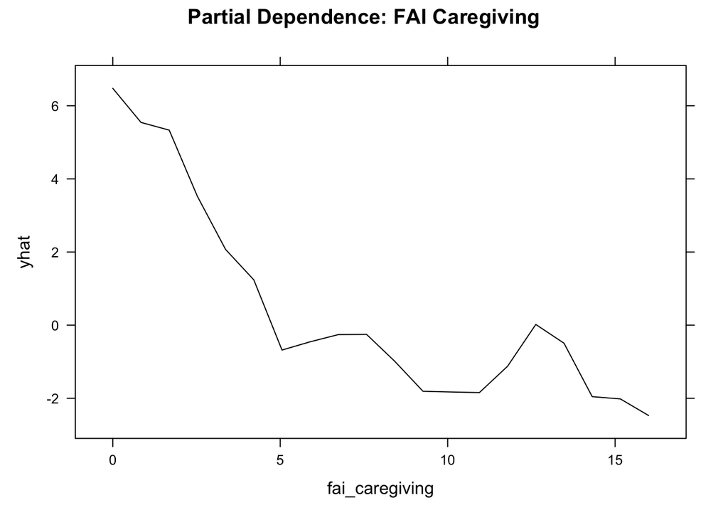

```r
# Load pdp package
library(pdp)

# Generate Partial Dependence Plot using pdp
pdp_caregiving <- partial(
  rf_model_regularized,
  pred.var = "fai_caregiving",
  train = balanced_fai
)
plotPartial(pdp_caregiving, main = "Partial Dependence: FAI Caregiving")
```

## Conclusion

Predictive Power of FAI Scales:

- Both models indicate that the FAI scales are strong predictors of illness severity.
- The Random Forest model, with near-perfect accuracy, demonstrates the predictive utility of the scales.

Applicability of the Models:

- The multinomial logistic regression model provides interpretable insights but is limited by its assumptions.
- The Random Forest model excels in predictive accuracy and robustness, making it suitable for practical applications.

In summary, the FAI scales demonstrate utility in predicting illness severity, but their discriminative ability varies across models. Future work should explore additional predictors or refine the classification.

## Final Conclusions

The regularized Random Forest model provides robust and interpretable results, achieving 97% test accuracy. These findings support the implementation of the FAI scales in practical contexts to identify caregivers requiring tailored interventions. Future studies could explore additional contextual variables and advanced modeling techniques to further enhance predictive accuracy.